# Silicate–Melt Equilibria and the Phase Rule

Dr. Ahmad Redaa

26-10-2025

# Why equilibrium matters in petrology

- Magmas **crystallize**; rocks **melt** and **transform**.
- Which phases (minerals/liquid) appear **depends on**: Temperature **T**, Pressure **P**, Composition **X**.
- Phase relations are our “**maps**” for igneous & metamorphic processes.

> Core question: *Which phases can coexist at given T–P–X?*

# What do we mean by *phase* and *component*?

- **Phase (P):** physically distinct, mechanically separable part (e.g., crystal, melt, vapor).
- **Component (C):** minimal set of chemical “ingredients” to describe all phases present.
- **System:** the portion we’re studying (e.g., pure water, a basaltic melt).

| Term | Example (everyday) | Example (petrology) |
| --- | --- | --- |
| Phase | ice / liquid / vapor | olivine / melt / vapor |
| Component | H₂O | SiO₂, MgO, FeO, … |
| System | a pot of water | magma + crystals in a chamber |

# Warm-up system: Pure water (H₂O)

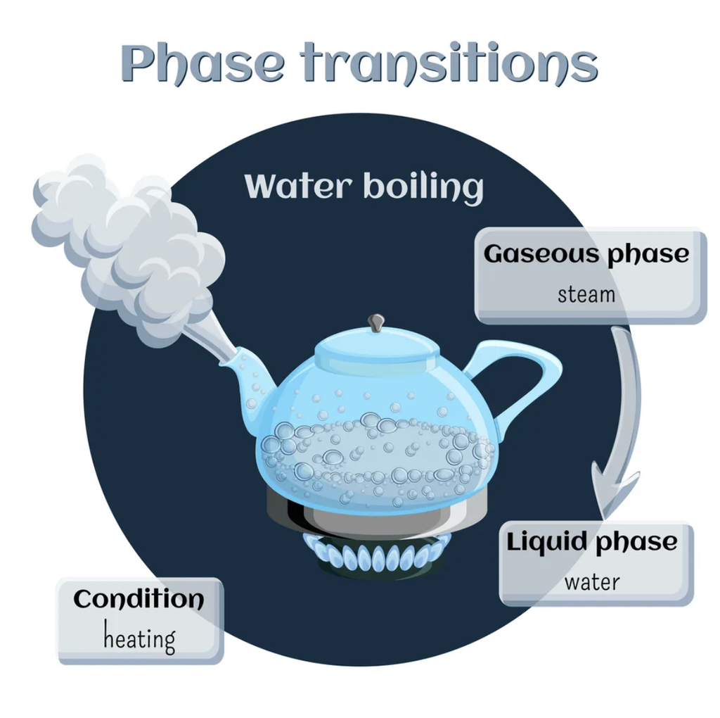

Boiling water system.

Source: [VectorStock](https://www.vectorstock.com/royalty-free-vector/water-boiling-phase-change-vector-44558174)

**C = 1** (one component), with possible phases: - Solid (ice) - Liquid (water) - Vapor (steam)

We’ll use water to see **how equilibrium conditions are constrained**.

# The Gibbs Phase Rule

We’ll use the rule, not its derivation:

$$F = C - P + 2$$

- **F**: degrees of freedom (independent variables you can change without changing the number of phases present).
- For lab/diagram cases at constant P *or* constant T, we often use reduced forms later. For now, keep the general form.

> For **water** (C = 1): $F = 3 - P$.

# Apply Phase Rule to water

| Phases present | P | F = 3 − P | Meaning (at equilibrium) |
| --- | --- | --- | --- |
| Ice *or* Liquid *or* Vapor | 1 | 2 | You can vary **T and P** independently and stay in that single-phase field. |
| Liquid + Vapor | 2 | 1 | You can vary **one** variable; the other is fixed by the **boiling** curve. |
| Ice + Liquid | 2 | 1 | Must stay on the **melting/freezing** curve. |
| Ice + Liquid + Vapor | 3 | 0 | **Triple point**: T and P **fixed**; any change loses a phase. |

# Phase regions vs. coexistence lines

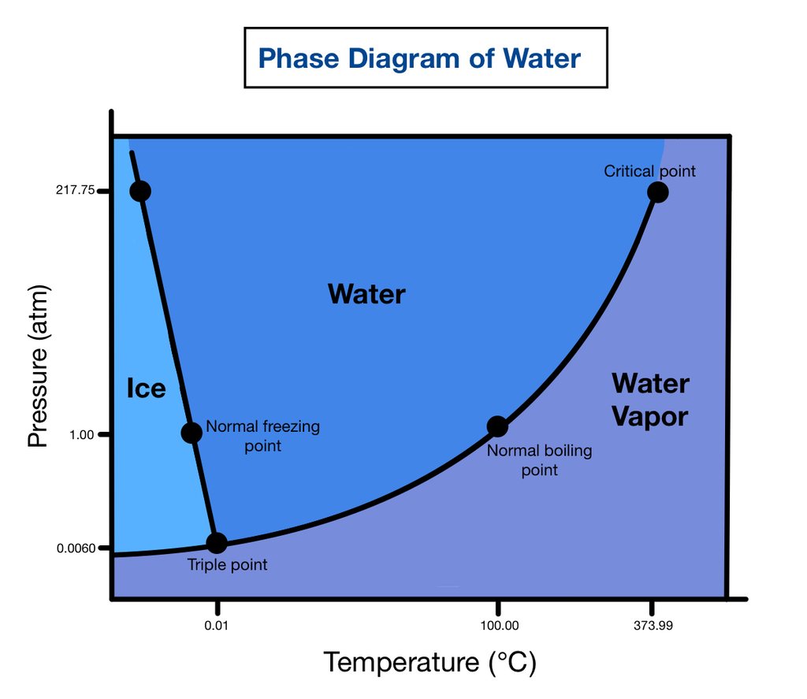

Phase Diagram of Water.

Source: [https://www.expii.com](https://www.expii.com/t/phase-change-diagram-of-water-overview-importance-8031)

- Regions on T–P diagram = **single phase** (F = 2 for water).
- **Lines** = two-phase equilibrium (F = 1).
- **Point** where three lines meet = triple point (F = 0).

# Takeaway from water

- Equilibrium **limits freedom**: more coexisting phases → **fewer** degrees of freedom.
- This logic **directly transfers** to minerals + melt in rocks.
- Now, let’s scale up.

# Unary system: SiO₂ polymorphs

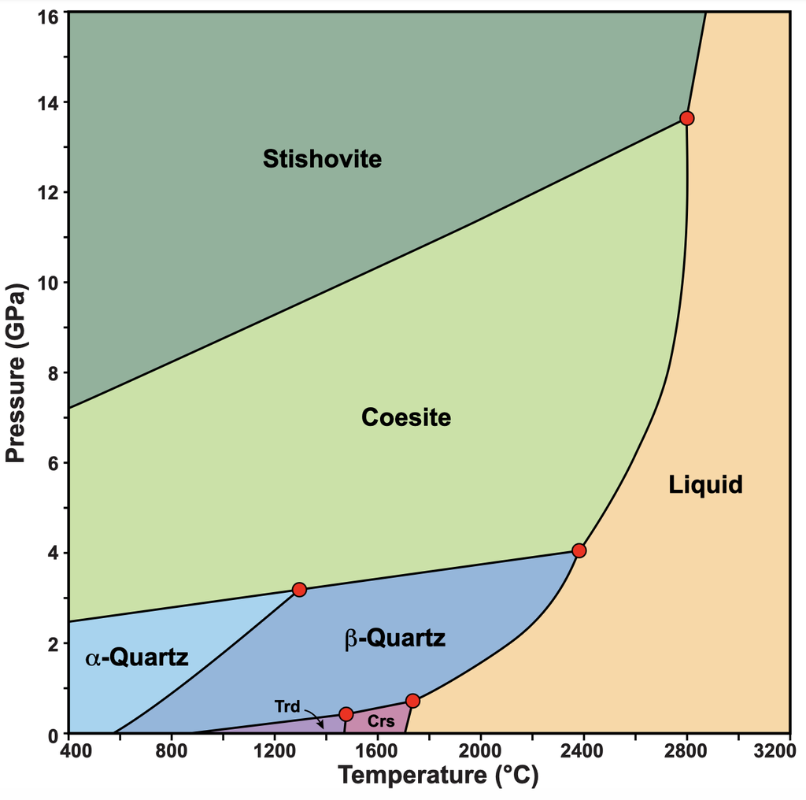

SiO₂ equilibrium phase diagram.

Source: [https://www.science.smith.edu](https://www.science.smith.edu/~jbrady/petrology/igrocks-diagrams/unary/SiO2.php)

- **C = 1** (SiO₂) with multiple **phases**: quartz, tridymite, cristobalite (+ melt).
- Each phase is stable over certain **T–P** ranges.
- Triple point(s) where three phases coexist → **F = 0**.

**Teaching points:** - Same counting as water: 1 component, multiple phases. - **Phase boundaries** mark where one phase replaces another at equilibrium.

# Binary systems: two components

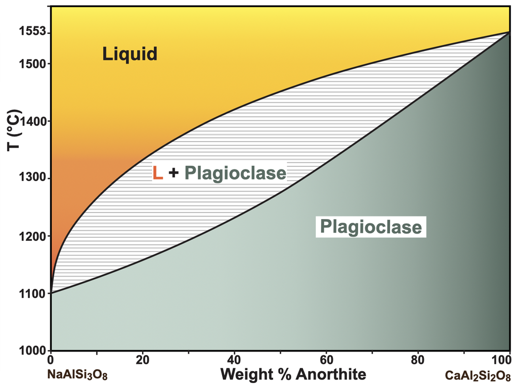

NaAlSi₃O₈–CaAl₂Si₂O₈ equilibrium phase diagram.

Source: [https://www.science.smith.edu](https://www.science.smith.edu/~jbrady/petrology/igrocks-diagrams/binary/albite-anorthite.php)

Example: **Albite (Ab) – Anorthite (An)** feldspar series  
**C = 2**, phases can include **melt** and one or more **solids**.

# Reading a binary phase diagram (Ab–An)

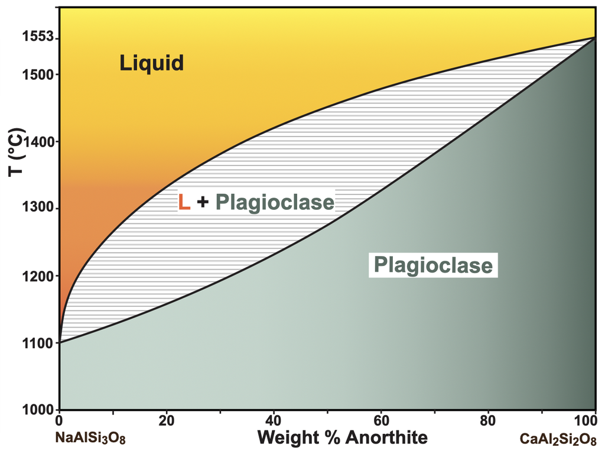

NaAlSi₃O₈–CaAl₂Si₂O₈ equilibrium phase diagram.

Source: [https://www.science.smith.edu](https://www.science.smith.edu/~jbrady/petrology/igrocks-diagrams/binary/albite-anorthite.php)

# Phase rule insight on binary eutectic

At the **eutectic** (isobaric, isothermal diagram section): - Coexisting phases: **Solid A + Solid B + Liquid** → $P = 3$ - Components: **C = 2** - At variable T and composition axes (P held fixed in lab), the eutectic is **invariant** → effectively **no freedom**: fixed T and composition of liquid and solids at that point.

> Intuition: maximum coexistence = minimum freedom.

# Petrological meaning (binary)

- **Crystallization sequence**: which phase appears first depends on **bulk composition** and **liquidus shape**.
- **Fractional crystallization**: early crystals remove elements from melt → melt composition **evolves**.
- **Natural link**: explains why basaltic magmas can differentiate into diverse rock types.

# Ternary systems: three components

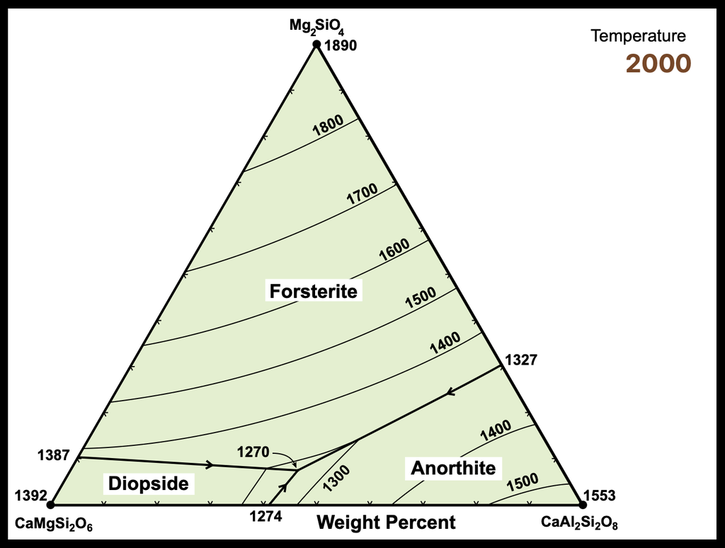

CaMgSi₂O₆–Mg₂SiO₄–CaAl₂Si₂O₈ diagram.

Source: [Smith College Petrology Resources](https://www.science.smith.edu/~jbrady/petrology/igrocks-diagrams/ternary/diopside-forsterite-anorthite.php)

Example (basalt analog): **Diopside–Anorthite–Forsterite** (Di–An–Fo)  
- **C = 3**, phases include **melt** and one or more **solids**. - Plot on a **triangle**: each vertex = 100% of one component; any point inside = mixture.

Key features: - **Cotectic lines**: melt coexists with **two solids**.  
- **Ternary eutectic** (invariant trough point): melt + **three** solids.

# Following paths on a ternary diagram

- Start with bulk melt composition (a point in the triangle).
- On cooling, composition of the **residual melt** travels along **liquid paths** toward **cotectics**.
- Where **three solids** and melt meet → **ternary eutectic** (invariant).

> Practice prompt (in-class): mark a starting melt and sketch its liquid line of descent to the eutectic.

# Comparing systems: same logic, growing complexity

[output not shown]

> The **phase rule** constrains all of them.